\title{About random forests} \author{Andy} \maketitle

# Combining decision trees into a random forest

> These are essentially a collection of decision trees, where each tree is slightly different from the others. In contrast to bagged decision trees, each tree in a random forest is trained on a slightly different subset of data features.

> (...) Because of the randomness of the procedure, each tree in the forest will overfit the data in a slightly different way. The effect of overfitting can then be reduced by averaging the predictions of the individual trees \cite{Beyeler2017}

# Understanding the shortcomings of decision trees

Here, we choose to generate 100 data samles belonging to two half circles, in combination with some Gaussian noise with standard deviation 0.25

```python
from sklearn.datasets import make_moons
X, y,  = make_moons(n_samples=100, noise=0.25, random_state=100)
```

```python
# visualization
import matplotlib.pyplot as plt
%matplotlib inline
plt.style.use('ggplot')
```

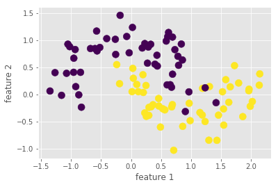

```python
plt.scatter(X[:, 0], X[:, 1], s=100, c=y)
plt.xlabel('feature 1')
plt.ylabel('feature 2')
```

(...) decision trees are tempted to overlook the general arrangement of data points (...) and instead focus on the noise in the data.

```python
# split the data 75-25

from sklearn.model_selection import train_test_split
X_train, X_test, y_train, y_test = train_test_split(X, y, \
                                                    random_state=100)
```

```python
# let's see how the decision boundary changes
import numpy as np
def plot_decision_boundary(classifier, X_test, y_test):
    # create dense 2D grid
    h = 0.02 #step size
    x_min = X_test[:, 0].min() - 1
    x_max = X_test[:, 0].max() + 1
    y_min = X_test[:, 1].min() - 1
    y_max = X_test[:, 1].max() + 1
    xx, yy = np.meshgrid(np.arange(x_min, x_max, h),\
                        np.arange(y_min, y_max, h))
    # classify every point on the grid
    X_hypo = np.c_[xx.ravel().astype(np.float32),\
                  yy.ravel().astype(np.float32)]
    ret = classifier.predict(X_hypo)
    # if predict returns a tuple, it's an opencv classifier,
    # otherwise is scikit-learn
    if isinstance(ret, tuple):
        zz = ret[1]
    else:
        zz = ret
    zz = zz.reshape(xx.shape)
    # Use predicted target labels zz to color
    plt.contourf(xx, yy, zz, cmap=plt.cm.coolwarm, alpha=0.8)
    # draw points
    plt.scatter(X_test[:, 0], X_test[:, 1], c=y_test, s=200)
```

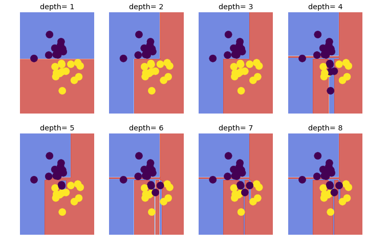

```python
# fit trees of different depths
from sklearn.tree import DecisionTreeClassifier
plt.figure(figsize=(12,8))
for depth in range(1,9):
    plt.subplot(2,4,depth)
    tree = DecisionTreeClassifier(max_depth=depth)
    tree.fit(X_train, y_train)
    y_test = tree.predict(X_test)
    plot_decision_boundary(tree, X_test, y_test)
    # prettier output
    plt.axis('off')
    plt.title('depth= %d' % depth)
```

> Recall the procedure of a decision tree: at every node in the tree, the algorithm picks a feature to split, either along the x-axis or along the y-axis. For example, a tree of depth=1 has only one node and, thus, makes only one decision.

> (...) As we continue to build deeper and deeper trees, we notice something strange: the deeper the tree, the more likely it is to get strangely shaped decision regions, such as the tall and skinny patches in the rightmost panel of the lower row. It's clear that these patches are more a result of the noise in the data rather than some characteristic of the underlying data distribution. This is an indication that most of the trees are overfitting the data \cite{Beyeler2017}.

There are at least two different ways to make a decision tree less powerful:

- Train the tree only on a subset of the data
- Train the tree only on a subset of the features

Random forests do just that. In addition, they repeat the experiment many times by building an ensemble of trees, each of which is trained on a randomly chosen subset of data samples and/or features.

# Implementing a random forest

```python
# use RTrees_create from ml module
import cv2
rtree = cv2.ml.RTrees_create()
```

parameters:

- `setMaxDepth`: This sets the maximum possible depth of each tree in the ensemble. The actual obtained depth may be smaller if other termination criteria are met first.
- `setMinSampleCount`: This sets the minimum number of samples that a node can contain for it to get split.
- `setMaxCategories`: This sets the maximum number of categories allowed. Setting the number of categories to a smaller value than the actual number of classes in the data performs subset estimation.
- `setTermCriteria`: This sets the termination criteria of the algorithm. This is also where you set the number of trees in the forest.

```python
# specify no. of trees and exit parameters
n_trees = 10
eps = 0.01
criteria = (cv2.TERM_CRITERIA_MAX_ITER + cv2.TERM_CRITERIA_EPS,\
           n_trees, eps)
rtree.setTermCriteria(criteria)
```

```python
# train classifier
rtree.train(X_train.astype(np.float32), cv2.ml.ROW_SAMPLE, y_train)
```

```
True
```

```python
# predict labels
_, y_hat = rtree.predict(X_test.astype(np.float32))
```

```python
# evaluate the model
from sklearn.metrics import accuracy_score
accuracy_score(y_test, y_hat)
# ~83.9%
```

```
0.88
```

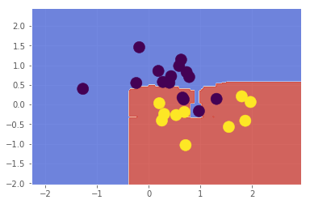

```python
# let's see the predicted labels
plot_decision_boundary(rtree, X_test, y_test)
```

# Implement a random forest on scikit-learn

```python
from sklearn.ensemble import RandomForestClassifier
forest = RandomForestClassifier(n_estimators=10,\
                               random_state=200)
```

parameters:

- `n_estimators`: This specifies the number of trees in the forest.
- `criterion`: This specifies the node splitting criterion. Setting `criterion='gini'` implements the Gini impurity, whereas setting `criterion='entropy'` implements information gain.
- `max_features`: This specifies the number (or fraction) of features to consider at each node split.
- `max_depth`: This specifies the maximum depth of each tree.
- `min_samples`: This specifies the minimum number of samples required to split a node.

```python
# fit and score the classifier
forest.fit(X_train, y_train)
forest.score(X_test, y_test)
# ~83.9%
```

```
0.88
```

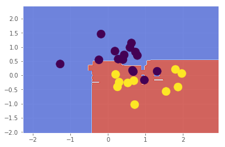

```python
# plot this forest decision
plot_decision_boundary(forest, X_test, y_test)
```

# Implementing extremely randomized trees

> In **extremely randomized trees** (see `ExtraTreesClassifier` and `ExtraTreesRegressor` classes), the randomness is taken even further than in random forests. Remember how decision trees usually choose a threshold for every feature so that the purity of the node split is maximized. Extremely randomized trees, on the other hand, choose these thresholds at random. The best one of these randomly-generated thresholds is then used as the splitting rule.

```python
from sklearn.ensemble import ExtraTreesClassifier
extra_tree = ExtraTreesClassifier(n_estimators=10,\
                                random_state=100)
```

```python
# Contrast a single tree, a random forest and extremely
# randomized trees with the iris dataset

from sklearn.datasets  import load_iris
iris = load_iris()
X = iris.data[:, [0, 2]]
y = iris.target
```

```python
X_train, X_test, y_train, y_test = train_test_split(X, y, random_state=100)
```

```python
# fit and score the tree object
extra_tree.fit(X_train, y_train)
extra_tree.score(X_test, y_test)
# ~92.1%
```

```
0.9210526315789473
```

```python
# comparison with a random forest
forest = RandomForestClassifier(n_estimators=10,\
                               random_state=100)
forest.fit(X_train, y_train)
forest.score(X_test, y_test)
# ~92.1%
```

```
0.9210526315789473
```

```python
# the difference then lies in the boundary

classifiers = [\
              (1, 'decision tree', tree),\
              (2, 'random forest', forest),\
              (3, 'extremely randomized trees', extra_tree)
              ]
```

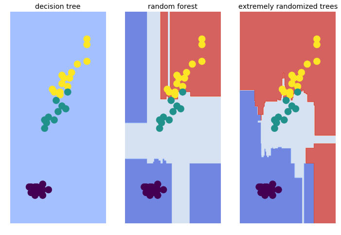

```python
# plot these classifiers
plt.figure(figsize=(12,8))
for sp, name, model in classifiers:
    plt.subplot(1, 3, sp)
    plot_decision_boundary(model, X_test, y_test)
    plt.title(name)
    plt.axis('off')
```

> The random forest is able to more clearly separate the cloud of data points in the lower left of the decision landscape. However, only extremely randomized trees were able to corner the cloud of data points towards the center of the landscape from all sides \cite{Beyeler2017}.

# References

(Beyeler, 2017) Michael Beyeler, ``*Machine Learning for OpenCV: Intelligent image processing with Python*'', 2017. [online](https://www.amazon.com/Machine-Learning-OpenCV-Intelligent-processing/dp/1783980281?SubscriptionId=AKIAIOBINVZYXZQZ2U3A&tag=chimbori05-20&linkCode=xm2&camp=2025&creative=165953&creativeASIN=1783980281)